# R Notebook

Load packages and data

```r
library(rjags); library(ggplot2); library(lme4); library(reshape2)
library(rstan); library(rstanarm); library(loo)
options(mc.cores = parallel::detectCores())
```

Update: The mixed effects actually does work. Here’s why: To test whether vaporfly varies across runner, we add the runner random effect first, and then we add the T:runner or the F:runner to find the estimate when that runner was/wasn’t wearing the vaporfly shoe. To find the effect for that runner, we simply find the difference between the two, F - T and see whether that is significantly less than 0. We could average those differences across runner to find the overall effect of vaporfly across runners.

### Final plan:

Model 1: time ~ vaporfly*gender + age*gender + (1|marathon) + (1|vaporfly:marathon) + (1|match_name) + (1|vaporfly:match_name) Model 2: time ~ vaporfly*gender + age*gender + (1|marathon) + (1|vaporfly:marathon) + (1|match_name) + (1|vaporfly:match_name), weights Model 3: time ~ vaporfly*gender + age*gender + (1+age|marathon) + (1|marathon) + (1|vaporfly:marathon) + (1|match_name) + (1|vaporfly:match_name) Model 4: (6758.3) time ~ vaporfly*gender + age*gender + (1+age|marathon) + (1|marathon) + (1|vaporfly:marathon) + (1|match_name) + (1|vaporfly:match_name), weights Model 5: log(time) with the best fitting model above

## Model 1

Stan code

```r
ml.a.1.stancode <- '
data {
  int<lower=1> N;                               //Number of observations
  int<lower=1> P;                               //Number of predictors in X
  int<lower=1> M;                               //Number of marathons
  int<lower=1> Mp;                              //Number of marathon predictors
  int<lower=1> R;                               //Number of runners
  int<lower=1> VR;                              //Number of levels for vaporfly:runner
  int<lower=1> VM;                              //Number of levels for vaporfly:marathon
  int<lower=1, upper=M> marathon[N];            //Index of marathons
  int<lower=1, upper=R> runner[N];              //Index of runners
  int<lower=1, upper=VR> vaporfly_runner[N];    //Index of vaporfly:runner
  int<lower=1, upper=VM> vaporfly_marathon[N];  //Index of vaporfly:marathon
  matrix[N,P] X;                                //Fixed effects model matrix
  matrix[N,Mp] Z_m;                             //Marathon-level random effects model matrix
  vector[N] y;                                  //Response variable
}

transformed data {
  vector[N] logy;                               //Log-transformed response variable

  logy = log(y);
}

parameters {
  vector[P] beta;                               //Vector of fixed-effects coefficients
  real<lower=0> sigma_r;                        //Runner-level variance
  real<lower=0> sigma_vr;                       //Vaporfly:runner-level variance
  real<lower=0> sigma_vm;                       //Vaporfly:marathon-level variance
  vector<lower=0>[Mp] sigma_m;                  //Vector for marathon-level variances (intercept and slope for age)
  cholesky_factor_corr[Mp] L_m;                 //Correlation vector (Cholesky decomposition) of marathon-level intercept and slope
  real<lower=0> sigma_e;                     //Error variance -- separate for each marathon
  vector[R] r_raw;                              //Vector of unscaled runner-level random intercepts
  vector[VR] vr_raw;                            //Vector of unscaled vaporfly:runner-level random intercepts
  vector[VM] vm_raw;                            //Vector of unscaled vaporfly:marathon-level random intercepts
  vector[Mp] m_raw[M];                          //Array of vectors of unscaled marathon-level random intercepts and slopes
}

transformed parameters {
  vector[R] r;                                  //Vector of scaled runner-level random intercepts
  vector[VR] vr;                                //Vector of scaled vaporfly:runner-level random intercepts
  vector[VM] vm;                                //Vector of scaled vaporfly:marathon-level random intercepts
  vector[Mp] m[M];                              //Array of vectors of scaled marathon-level random intercepts and slopes

  {
    matrix[Mp, Mp] Sigma_m;                     //Marathon-level intercept and slope covariance matrix
    r = sigma_r * r_raw;                        //Create scaled runner-level random intercepts
    vr = sigma_vr * vr_raw;                     //Create scaled vaporfly:runner-level random intercepts
    vm = sigma_vm * vm_raw;                     //Create scaled vaporfly:marathon-level random intercepts

    Sigma_m = diag_pre_multiply(sigma_m, L_m);  //Create marathon=level intercept and slope covariance matrix using Cholesky decomposition
    for (a in 1:M) {
      m[a] = Sigma_m * m_raw[a];                //Create scaled marathon-level random intercepts and slopes
    }
  }
}

model {
  r_raw ~ std_normal();                         //Standard normal prior on unscaled runner-level random intercepts. Has effect of r ~ Normal(0, r_sigma).
  vr_raw ~ std_normal();                        //Standard normal prior on unscaled vaporfly:runner-level random intercepts. Has effect of vr ~ Normal(0, vr_sigma).
  vm_raw ~ std_normal();                        //Standard normal prior on unscaled vaporfly:marathon-level random intercepts. Has effect of vm ~ Normal(0, vm_sigma).
  for (b in 1:M) {
    m_raw[b] ~ std_normal();                    //Standard normal prior on unscaled marathon-level random intercepts. Has effect of m ~ MultivariateNormal(c(0,0), Sigma_m).
  }
  L_m ~ lkj_corr_cholesky(1);                   //LKJ prior on Cholesky correlation vector. Imposes uniform prior on correlation between intercept and slope.
  sigma_r ~ cauchy(0,2);                        //Cauchy prior on runner-level hypervariance parameter.
  for (c in 1:Mp) {
    sigma_m[c] ~ cauchy(0,2);                   //Independent Cauchy priors on marathon-level intercept and slope hypervariance parameters.
  }
  sigma_vr ~ cauchy(0,2);                       //Cauchy prior on vaporfly:runner-level hypervariance parameter.
  sigma_vm ~ cauchy(0,2);                       //Cauchy prior on vaporfly:marathon-level hypervariance parameter.
  sigma_e ~ cauchy(0,2);                        //Cauchy prior on error variance.

  //Likelihood                                  //Normal likelihood function with mixed effects linear predictor and homoscedastic error variance assumption.
  for (i in 1:N) {
     y[i] ~ normal(X[i,]*beta + Z_m[i,]*m[marathon[i]] + r[runner[i]] + vr[vaporfly_runner[i]] + vm[vaporfly_marathon[i]], sigma_e);
  }
}

generated quantities {
  vector[N] residuals;                          //Vector for residuals
  vector[N] yhat;                               //Vector for estimated linear predictor
  vector[N] yhat_ppd;                           //Vector for posterior predictive distribution
  vector[N] log_lik;                            //Vector for log-likelihood values for WAIC calculation

  for (j in 1:N) {
    //Samples for the linear predictor yhat
    yhat[j] = (X[j,]*beta + Z_m[j,]*m[marathon[j]] + r[runner[j]] + vr[vaporfly_runner[j]] + vm[vaporfly_marathon[j]]);
    //Samples for the posterior predictive distribution, which includes error uncertainty
    yhat_ppd[j] = normal_rng((X[j,]*beta + Z_m[j,]*m[marathon[j]] + r[runner[j]] + vr[vaporfly_runner[j]] + vm[vaporfly_marathon[j]]), sigma_e);
    //Samples of log-likelihood for WAIC calculation
    log_lik[j] = normal_lpdf(y[j] | (X[j,]*beta + Z_m[j,]*m[marathon[j]] + r[runner[j]] + vr[vaporfly_runner[j]] + vm[vaporfly_marathon[j]]), sigma_e);
  }

  residuals = y - yhat;                         //Define residuals as y - hat

}

'
```

Define the data for stan

```r
ml.a.1.X <- model.matrix(~ vaporfly*gender + gender*age, data=shoes2)
ml.a.1.Z_m <- model.matrix(~ 1, data=shoes2)
ml.a.1.standata <- list(
  N = nrow(ml.a.1.X),
  P = ncol(ml.a.1.X),
  Mp = ncol(ml.a.1.Z_m),
  M = length(unique(as.integer(factor(shoes2$marathon)))),
  R = length(unique(as.integer(factor(shoes2$match_name)))),
  VM = length(unique(as.integer(factor(shoes2$vaporfly_marathon)))),
  VR = length(unique(as.integer(factor(shoes2$vaporfly_runner)))),
  marathon = as.integer(factor(shoes2$marathon)),
  runner = as.integer(factor(shoes2$match_name)),
  vaporfly_marathon = as.integer(factor(shoes2$vaporfly_marathon)),
  vaporfly_runner = as.integer(factor(shoes2$vaporfly_runner)),
  X = ml.a.1.X,
  Z_m = ml.a.1.Z_m,
  y = shoes2$time_minutes
)
```

Set initial values

```r
Mp = ncol(ml.a.1.Z_m)
M = length(unique(as.integer(factor(shoes2$marathon))))
R = length(unique(as.integer(factor(shoes2$match_name))))
VM = length(unique(as.integer(factor(shoes2$vaporfly_marathon))))
VR = length(unique(as.integer(factor(shoes2$vaporfly_runner))))
marathon = as.integer(factor(shoes2$marathon))
runner = as.integer(factor(shoes2$match_name))
vaporfly_marathon = as.integer(factor(shoes2$vaporfly_marathon))
vaporfly_runner = as.integer(factor(shoes2$vaporfly_runner))

initf2.norm <- function(chain_id = 1) {
  # cat("chain_id =", chain_id, "\n")
  list(beta = array(rnorm(ncol(ml.a.1.X), sd=0.1), dim = c(ncol(ml.a.1.X))),
       sigma_r = 1,
       sigma_vr = 1,
       sigma_vm = 1,
       sigma_m = array(rlnorm(Mp, sdlog = 0.1), dim = Mp),
       sigma_e = array(rlnorm(1, sdlog = 0.1), dim=1),
       r_raw = array(rnorm(R, sd=0.1), dim=R),
       vr_raw = array(rnorm(VR, sd=0.1), dim=VR),
       vm_raw = array(rnorm(VM, sd=0.1), dim=VM),
       m_raw = array(rnorm(M*2, sd=0.1), dim = c(M,ncol(ml.a.1.Z_m)))
       )
}

# generate a list of lists to specify initial values
n_chains <- 3
init_ll.norm <- lapply(1:n_chains, function(id) initf2.norm(chain_id = id))
```

Run the model

```r
ml.a.1.stanfit <- stan(
  model_code = ml.a.1.stancode,
  data=ml.a.1.standata,
  control = list(max_treedepth = 15, adapt_delta=0.9),
  init = init_ll.norm,
  chains=3,
  warmup=3000,
  iter=11000,
  cores=3
)
```

WAIC

```r
ml.a.1.stanfit.loglik <- extract_log_lik(ml.a.1.stanfit)
fbar <- colMeans(exp(ml.a.1.stanfit.loglik))
Pw <- sum(apply(ml.a.1.stanfit.loglik, 2, var))
WAIC <- -2*sum(log(fbar)) + 2*Pw
WAIC #6850.8, 6913.2, 6909
```

## Model 2 – different variances for marathon

Stan code

```r
ml.a.2.stancode <- '
data {
  int<lower=1> N;                               //Number of observations
  int<lower=1> P;                               //Number of predictors in X
  int<lower=1> M;                               //Number of marathons
  int<lower=1> Mp;                              //Number of marathon predictors
  int<lower=1> R;                               //Number of runners
  int<lower=1> VR;                              //Number of levels for vaporfly:runner
  int<lower=1> VM;                              //Number of levels for vaporfly:marathon
  int<lower=1, upper=M> marathon[N];            //Index of marathons
  int<lower=1, upper=R> runner[N];              //Index of runners
  int<lower=1, upper=VR> vaporfly_runner[N];    //Index of vaporfly:runner
  int<lower=1, upper=VM> vaporfly_marathon[N];  //Index of vaporfly:marathon
  matrix[N,P] X;                                //Fixed effects model matrix
  matrix[N,Mp] Z_m;                             //Marathon-level random effects model matrix
  vector[N] y;                                  //Response variable
}

transformed data {
  vector[N] logy;                               //Log-transformed response variable

  logy = log(y);
}

parameters {
  vector[P] beta;                               //Vector of fixed-effects coefficients
  real<lower=0> sigma_r;                        //Runner-level variance
  real<lower=0> sigma_vr;                       //Vaporfly:runner-level variance
  real<lower=0> sigma_vm;                       //Vaporfly:marathon-level variance
  vector<lower=0>[Mp] sigma_m;                  //Vector for marathon-level variances (intercept and slope for age)
  cholesky_factor_corr[Mp] L_m;                 //Correlation vector (Cholesky decomposition) of marathon-level intercept and slope
  real<lower=0> sigma_e[M];                     //Error variance -- separate for each marathon
  vector[R] r_raw;                              //Vector of unscaled runner-level random intercepts
  vector[VR] vr_raw;                            //Vector of unscaled vaporfly:runner-level random intercepts
  vector[VM] vm_raw;                            //Vector of unscaled vaporfly:marathon-level random intercepts
  vector[Mp] m_raw[M];                          //Array of vectors of unscaled marathon-level random intercepts and slopes
}

transformed parameters {
  vector[R] r;                                  //Vector of scaled runner-level random intercepts
  vector[VR] vr;                                //Vector of scaled vaporfly:runner-level random intercepts
  vector[VM] vm;                                //Vector of scaled vaporfly:marathon-level random intercepts
  vector[Mp] m[M];                              //Array of vectors of scaled marathon-level random intercepts and slopes

  {
    matrix[Mp, Mp] Sigma_m;                     //Marathon-level intercept and slope covariance matrix
    r = sigma_r * r_raw;                        //Create scaled runner-level random intercepts
    vr = sigma_vr * vr_raw;                     //Create scaled vaporfly:runner-level random intercepts
    vm = sigma_vm * vm_raw;                     //Create scaled vaporfly:marathon-level random intercepts

    Sigma_m = diag_pre_multiply(sigma_m, L_m);  //Create marathon=level intercept and slope covariance matrix using Cholesky decomposition
    for (a in 1:M) {
      m[a] = Sigma_m * m_raw[a];                //Create scaled marathon-level random intercepts and slopes
    }
  }
}

model {
  r_raw ~ std_normal();                         //Standard normal prior on unscaled runner-level random intercepts. Has effect of r ~ Normal(0, r_sigma).
  vr_raw ~ std_normal();                        //Standard normal prior on unscaled vaporfly:runner-level random intercepts. Has effect of vr ~ Normal(0, vr_sigma).
  vm_raw ~ std_normal();                        //Standard normal prior on unscaled vaporfly:marathon-level random intercepts. Has effect of vm ~ Normal(0, vm_sigma).
  for (b in 1:M) {
    m_raw[b] ~ std_normal();                    //Standard normal prior on unscaled marathon-level random intercepts. Has effect of m ~ MultivariateNormal(c(0,0), Sigma_m).
    sigma_e[b] ~ cauchy(0,2);                   //Independent Cauchy priors on error variances for each marathon.
  }
  L_m ~ lkj_corr_cholesky(1);                   //LKJ prior on Cholesky correlation vector. Imposes uniform prior on correlation between intercept and slope.
  sigma_r ~ cauchy(0,2);                        //Cauchy prior on runner-level hypervariance parameter.
  for (c in 1:Mp) {
    sigma_m[c] ~ cauchy(0,2);                   //Independent Cauchy priors on marathon-level intercept and slope hypervariance parameters.
  }
  sigma_vr ~ cauchy(0,2);                       //Cauchy prior on vaporfly:runner-level hypervariance parameter.
  sigma_vm ~ cauchy(0,2);                       //Cauchy prior on vaporfly:marathon-level hypervariance parameter.

  //Likelihood                                  //Normal likelihood function with mixed effects linear predictor and homoscedastic error variance assumption.
  for (i in 1:N) {
     y[i] ~ normal(X[i,]*beta + Z_m[i,]*m[marathon[i]] + r[runner[i]] + vr[vaporfly_runner[i]] + vm[vaporfly_marathon[i]], sigma_e[marathon[i]]);
  }
}

generated quantities {
  vector[N] residuals;                          //Vector for residuals
  vector[N] yhat;                               //Vector for estimated linear predictor
  vector[N] yhat_ppd;                           //Vector for posterior predictive distribution
  vector[N] log_lik;                            //Vector for log-likelihood values for WAIC calculation

  for (j in 1:N) {
    //Samples for the linear predictor yhat
    yhat[j] = (X[j,]*beta + Z_m[j,]*m[marathon[j]] + r[runner[j]] + vr[vaporfly_runner[j]] + vm[vaporfly_marathon[j]]);
    //Samples for the posterior predictive distribution, which includes error uncertainty
    yhat_ppd[j] = normal_rng((X[j,]*beta + Z_m[j,]*m[marathon[j]] + r[runner[j]] + vr[vaporfly_runner[j]] + vm[vaporfly_marathon[j]]), sigma_e[marathon[j]]);
    //Samples of log-likelihood for WAIC calculation
    log_lik[j] = normal_lpdf(y[j] | (X[j,]*beta + Z_m[j,]*m[marathon[j]] + r[runner[j]] + vr[vaporfly_runner[j]] + vm[vaporfly_marathon[j]]), sigma_e[marathon[j]]);
  }

  residuals = y - yhat;                         //Define residuals as y - hat

}

'
```

Define the data for stan

```r
ml.a.2.X <- model.matrix(~ vaporfly*gender + gender*age, data=shoes2)
ml.a.2.Z_m <- model.matrix(~ 1, data=shoes2)
ml.a.2.standata <- list(
  N = nrow(ml.a.2.X),
  P = ncol(ml.a.2.X),
  Mp = ncol(ml.a.2.Z_m),
  M = length(unique(as.integer(factor(shoes2$marathon)))),
  R = length(unique(as.integer(factor(shoes2$match_name)))),
  VM = length(unique(as.integer(factor(shoes2$vaporfly_marathon)))),
  VR = length(unique(as.integer(factor(shoes2$vaporfly_runner)))),
  marathon = as.integer(factor(shoes2$marathon)),
  runner = as.integer(factor(shoes2$match_name)),
  vaporfly_marathon = as.integer(factor(shoes2$vaporfly_marathon)),
  vaporfly_runner = as.integer(factor(shoes2$vaporfly_runner)),
  X = ml.a.2.X,
  Z_m = ml.a.2.Z_m,
  y = shoes2$time_minutes
)
```

Set initial values

```r
Mp = ncol(ml.a.2.Z_m)
M = length(unique(as.integer(factor(shoes2$marathon))))
R = length(unique(as.integer(factor(shoes2$match_name))))
VM = length(unique(as.integer(factor(shoes2$vaporfly_marathon))))
VR = length(unique(as.integer(factor(shoes2$vaporfly_runner))))
marathon = as.integer(factor(shoes2$marathon))
runner = as.integer(factor(shoes2$match_name))
vaporfly_marathon = as.integer(factor(shoes2$vaporfly_marathon))
vaporfly_runner = as.integer(factor(shoes2$vaporfly_runner))

initf2.norm <- function(chain_id = 1) {
  # cat("chain_id =", chain_id, "\n")
  list(beta = array(rnorm(ncol(ml.a.2.X), sd=0.1), dim = c(ncol(ml.a.2.X))),
       sigma_r = 1,
       sigma_vr = 1,
       sigma_vm = 1,
       sigma_m = array(rlnorm(Mp, sdlog = 0.1), dim = Mp),
       sigma_e = array(rlnorm(M, sdlog = 0.1), dim=M),
       r_raw = array(rnorm(R, sd=0.1), dim=R),
       vr_raw = array(rnorm(VR, sd=0.1), dim=VR),
       vm_raw = array(rnorm(VM, sd=0.1), dim=VM),
       m_raw = array(rnorm(M*2, sd=0.1), dim = c(M,ncol(ml.a.2.Z_m)))
       )
}

# generate a list of lists to specify initial values
n_chains <- 3
init_ll.norm <- lapply(1:n_chains, function(id) initf2.norm(chain_id = id))
```

Run the model

```r
ml.a.2.stanfit <- stan(
  model_code = ml.a.2.stancode,
  data=ml.a.2.standata,
  control = list(max_treedepth = 15, adapt_delta=0.9),
  init = init_ll.norm,
  chains=3,
  warmup=3000,
  iter=11000,
  cores=3
)
```

WAIC

```r
ml.a.2.stanfit.loglik <- extract_log_lik(ml.a.2.stanfit)
fbar <- colMeans(exp(ml.a.2.stanfit.loglik))
Pw <- sum(apply(ml.a.2.stanfit.loglik, 2, var))
WAIC <- -2*sum(log(fbar)) + 2*Pw
WAIC #6756.3, 6814.6, 6791.4
```

## Model 3 – Random age slope by marathon with homoscedastic error variance

Stan code

```r
ml.a.3.stancode <- '
data {
  int<lower=1> N;                               //Number of observations
  int<lower=1> P;                               //Number of predictors in X
  int<lower=1> M;                               //Number of marathons
  int<lower=1> Mp;                              //Number of marathon predictors
  int<lower=1> R;                               //Number of runners
  int<lower=1> VR;                              //Number of levels for vaporfly:runner
  int<lower=1> VM;                              //Number of levels for vaporfly:marathon
  int<lower=1, upper=M> marathon[N];            //Index of marathons
  int<lower=1, upper=R> runner[N];              //Index of runners
  int<lower=1, upper=VR> vaporfly_runner[N];    //Index of vaporfly:runner
  int<lower=1, upper=VM> vaporfly_marathon[N];  //Index of vaporfly:marathon
  matrix[N,P] X;                                //Fixed effects model matrix
  matrix[N,Mp] Z_m;                             //Marathon-level random effects model matrix
  vector[N] y;                                  //Response variable
}

transformed data {
  vector[N] logy;                               //Log-transformed response variable

  logy = log(y);
}

parameters {
  vector[P] beta;                               //Vector of fixed-effects coefficients
  real<lower=0> sigma_r;                        //Runner-level variance
  real<lower=0> sigma_vr;                       //Vaporfly:runner-level variance
  real<lower=0> sigma_vm;                       //Vaporfly:marathon-level variance
  vector<lower=0>[Mp] sigma_m;                  //Vector for marathon-level variances (intercept and slope for age)
  cholesky_factor_corr[Mp] L_m;                 //Correlation vector (Cholesky decomposition) of marathon-level intercept and slope
  real<lower=0> sigma_e;                     //Error variance -- separate for each marathon
  vector[R] r_raw;                              //Vector of unscaled runner-level random intercepts
  vector[VR] vr_raw;                            //Vector of unscaled vaporfly:runner-level random intercepts
  vector[VM] vm_raw;                            //Vector of unscaled vaporfly:marathon-level random intercepts
  vector[Mp] m_raw[M];                          //Array of vectors of unscaled marathon-level random intercepts and slopes
}

transformed parameters {
  vector[R] r;                                  //Vector of scaled runner-level random intercepts
  vector[VR] vr;                                //Vector of scaled vaporfly:runner-level random intercepts
  vector[VM] vm;                                //Vector of scaled vaporfly:marathon-level random intercepts
  vector[Mp] m[M];                              //Array of vectors of scaled marathon-level random intercepts and slopes

  {
    matrix[Mp, Mp] Sigma_m;                     //Marathon-level intercept and slope covariance matrix
    r = sigma_r * r_raw;                        //Create scaled runner-level random intercepts
    vr = sigma_vr * vr_raw;                     //Create scaled vaporfly:runner-level random intercepts
    vm = sigma_vm * vm_raw;                     //Create scaled vaporfly:marathon-level random intercepts

    Sigma_m = diag_pre_multiply(sigma_m, L_m);  //Create marathon=level intercept and slope covariance matrix using Cholesky decomposition
    for (a in 1:M) {
      m[a] = Sigma_m * m_raw[a];                //Create scaled marathon-level random intercepts and slopes
    }
  }
}

model {
  r_raw ~ std_normal();                         //Standard normal prior on unscaled runner-level random intercepts. Has effect of r ~ Normal(0, r_sigma).
  vr_raw ~ std_normal();                        //Standard normal prior on unscaled vaporfly:runner-level random intercepts. Has effect of vr ~ Normal(0, vr_sigma).
  vm_raw ~ std_normal();                        //Standard normal prior on unscaled vaporfly:marathon-level random intercepts. Has effect of vm ~ Normal(0, vm_sigma).
  for (b in 1:M) {
    m_raw[b] ~ std_normal();                    //Standard normal prior on unscaled marathon-level random intercepts. Has effect of m ~ MultivariateNormal(c(0,0), Sigma_m).
  }
  L_m ~ lkj_corr_cholesky(1);                   //LKJ prior on Cholesky correlation vector. Imposes uniform prior on correlation between intercept and slope.
  sigma_r ~ cauchy(0,2);                        //Cauchy prior on runner-level hypervariance parameter.
  for (c in 1:Mp) {
    sigma_m[c] ~ cauchy(0,2);                   //Independent Cauchy priors on marathon-level intercept and slope hypervariance parameters.
  }
  sigma_vr ~ cauchy(0,2);                       //Cauchy prior on vaporfly:runner-level hypervariance parameter.
  sigma_vm ~ cauchy(0,2);                       //Cauchy prior on vaporfly:marathon-level hypervariance parameter.
  sigma_e ~ cauchy(0,2);                        //Cauchy prior on error variance.

  //Likelihood                                  //Normal likelihood function with mixed effects linear predictor and homoscedastic error variance assumption.
  for (i in 1:N) {
     y[i] ~ normal(X[i,]*beta + Z_m[i,]*m[marathon[i]] + r[runner[i]] + vr[vaporfly_runner[i]] + vm[vaporfly_marathon[i]], sigma_e);
  }
}

generated quantities {
  vector[N] residuals;                          //Vector for residuals
  vector[N] yhat;                               //Vector for estimated linear predictor
  vector[N] yhat_ppd;                           //Vector for posterior predictive distribution
  vector[N] log_lik;                            //Vector for log-likelihood values for WAIC calculation

  for (j in 1:N) {
    //Samples for the linear predictor yhat
    yhat[j] = (X[j,]*beta + Z_m[j,]*m[marathon[j]] + r[runner[j]] + vr[vaporfly_runner[j]] + vm[vaporfly_marathon[j]]);
    //Samples for the posterior predictive distribution, which includes error uncertainty
    yhat_ppd[j] = normal_rng((X[j,]*beta + Z_m[j,]*m[marathon[j]] + r[runner[j]] + vr[vaporfly_runner[j]] + vm[vaporfly_marathon[j]]), sigma_e);
    //Samples of log-likelihood for WAIC calculation
    log_lik[j] = normal_lpdf(y[j] | (X[j,]*beta + Z_m[j,]*m[marathon[j]] + r[runner[j]] + vr[vaporfly_runner[j]] + vm[vaporfly_marathon[j]]), sigma_e);
  }

  residuals = y - yhat;                         //Define residuals as y - hat

}

'
```

Define the data for stan

```r
ml.a.3.X <- model.matrix(~ vaporfly*gender + gender*age, data=shoes2)
ml.a.3.Z_m <- model.matrix(~ 1 + age, data=shoes2)
ml.a.3.standata <- list(
  N = nrow(ml.a.3.X),
  P = ncol(ml.a.3.X),
  Mp = ncol(ml.a.3.Z_m),
  M = length(unique(as.integer(factor(shoes2$marathon)))),
  R = length(unique(as.integer(factor(shoes2$match_name)))),
  VM = length(unique(as.integer(factor(shoes2$vaporfly_marathon)))),
  VR = length(unique(as.integer(factor(shoes2$vaporfly_runner)))),
  marathon = as.integer(factor(shoes2$marathon)),
  runner = as.integer(factor(shoes2$match_name)),
  vaporfly_marathon = as.integer(factor(shoes2$vaporfly_marathon)),
  vaporfly_runner = as.integer(factor(shoes2$vaporfly_runner)),
  X = ml.a.3.X,
  Z_m = ml.a.3.Z_m,
  y = shoes2$time_minutes
)
```

Set initial values

```r
Mp = ncol(ml.a.3.Z_m)
M = length(unique(as.integer(factor(shoes2$marathon))))
R = length(unique(as.integer(factor(shoes2$match_name))))
VM = length(unique(as.integer(factor(shoes2$vaporfly_marathon))))
VR = length(unique(as.integer(factor(shoes2$vaporfly_runner))))
marathon = as.integer(factor(shoes2$marathon))
runner = as.integer(factor(shoes2$match_name))
vaporfly_marathon = as.integer(factor(shoes2$vaporfly_marathon))
vaporfly_runner = as.integer(factor(shoes2$vaporfly_runner))

initf2.norm <- function(chain_id = 1) {
  # cat("chain_id =", chain_id, "\n")
  list(beta = array(rnorm(ncol(ml.a.3.X), sd=0.1), dim = c(ncol(ml.a.3.X))),
       sigma_r = 1,
       sigma_vr = 1,
       sigma_vm = 1,
       sigma_m = array(rlnorm(Mp, sdlog = 0.1), dim = Mp),
       sigma_e = array(rlnorm(M, sdlog = 0.1), dim=M),
       r_raw = array(rnorm(R, sd=0.1), dim=R),
       vr_raw = array(rnorm(VR, sd=0.1), dim=VR),
       vm_raw = array(rnorm(VM, sd=0.1), dim=VM),
       m_raw = array(rnorm(M*2, sd=0.1), dim = c(M,2))
       )
}

# generate a list of lists to specify initial values
n_chains <- 3
init_ll.norm <- lapply(1:n_chains, function(id) initf2.norm(chain_id = id))
```

Run the model

```r
ml.a.3.stanfit <- stan(
  model_code = ml.a.3.stancode,
  data=ml.a.3.standata,
  control = list(max_treedepth = 15, adapt_delta=0.9),
  init = init_ll.norm,
  chains=4,
  warmup=1000,
  iter=2000,
  cores=4
)
```

WAIC

```r
ml.a.3.stanfit.loglik <- extract_log_lik(ml.a.3.stanfit)
fbar <- colMeans(exp(ml.a.3.stanfit.loglik))
Pw <- sum(apply(ml.a.3.stanfit.loglik, 2, var))
WAIC <- -2*sum(log(fbar)) + 2*Pw
WAIC #6905, #6912.4
```

## Model 4 – Random age slope by marathon with heteroscedastic error variance

Stan code

```r
ml.a.4.stancode <- '
data {
  int<lower=1> N;                               //Number of observations
  int<lower=1> P;                               //Number of predictors in X
  int<lower=1> M;                               //Number of marathons
  int<lower=1> Mp;                              //Number of marathon predictors
  int<lower=1> R;                               //Number of runners
  int<lower=1> VR;                              //Number of levels for vaporfly:runner
  int<lower=1> VM;                              //Number of levels for vaporfly:marathon
  int<lower=1, upper=M> marathon[N];            //Index of marathons
  int<lower=1, upper=R> runner[N];              //Index of runners
  int<lower=1, upper=VR> vaporfly_runner[N];    //Index of vaporfly:runner
  int<lower=1, upper=VM> vaporfly_marathon[N];  //Index of vaporfly:marathon
  matrix[N,P] X;                                //Fixed effects model matrix
  matrix[N,Mp] Z_m;                             //Marathon-level random effects model matrix
  vector[N] y;                                  //Response variable
}

transformed data {
  vector[N] logy;                               //Log-transformed response variable

  logy = log(y);
}

parameters {
  vector[P] beta;                               //Vector of fixed-effects coefficients
  real<lower=0> sigma_r;                        //Runner-level variance
  real<lower=0> sigma_vr;                       //Vaporfly:runner-level variance
  real<lower=0> sigma_vm;                       //Vaporfly:marathon-level variance
  vector<lower=0>[Mp] sigma_m;                  //Vector for marathon-level variances (intercept and slope for age)
  cholesky_factor_corr[Mp] L_m;                 //Correlation vector (Cholesky decomposition) of marathon-level intercept and slope
  real<lower=0> sigma_e[M];                     //Error variance -- separate for each marathon
  vector[R] r_raw;                              //Vector of unscaled runner-level random intercepts
  vector[VR] vr_raw;                            //Vector of unscaled vaporfly:runner-level random intercepts
  vector[VM] vm_raw;                            //Vector of unscaled vaporfly:marathon-level random intercepts
  vector[Mp] m_raw[M];                          //Array of vectors of unscaled marathon-level random intercepts and slopes
}

transformed parameters {
  vector[R] r;                                  //Vector of scaled runner-level random intercepts
  vector[VR] vr;                                //Vector of scaled vaporfly:runner-level random intercepts
  vector[VM] vm;                                //Vector of scaled vaporfly:marathon-level random intercepts
  vector[Mp] m[M];                              //Array of vectors of scaled marathon-level random intercepts and slopes

  {
    matrix[Mp, Mp] Sigma_m;                     //Marathon-level intercept and slope covariance matrix
    r = sigma_r * r_raw;                        //Create scaled runner-level random intercepts
    vr = sigma_vr * vr_raw;                     //Create scaled vaporfly:runner-level random intercepts
    vm = sigma_vm * vm_raw;                     //Create scaled vaporfly:marathon-level random intercepts

    Sigma_m = diag_pre_multiply(sigma_m, L_m);  //Create marathon=level intercept and slope covariance matrix using Cholesky decomposition
    for (a in 1:M) {
      m[a] = Sigma_m * m_raw[a];                //Create scaled marathon-level random intercepts and slopes
    }
  }
}

model {
  r_raw ~ std_normal();                         //Standard normal prior on unscaled runner-level random intercepts. Has effect of r ~ Normal(0, r_sigma).
  vr_raw ~ std_normal();                        //Standard normal prior on unscaled vaporfly:runner-level random intercepts. Has effect of vr ~ Normal(0, vr_sigma).
  vm_raw ~ std_normal();                        //Standard normal prior on unscaled vaporfly:marathon-level random intercepts. Has effect of vm ~ Normal(0, vm_sigma).
  for (b in 1:M) {
    m_raw[b] ~ std_normal();                    //Standard normal prior on unscaled marathon-level random intercepts. Has effect of m ~ MultivariateNormal(c(0,0), Sigma_m).
    sigma_e[b] ~ cauchy(0,2);                   //Independent Cauchy priors on error variances for each marathon.
  }
  L_m ~ lkj_corr_cholesky(1);                   //LKJ prior on Cholesky correlation vector. Imposes uniform prior on correlation between intercept and slope.
  sigma_r ~ cauchy(0,2);                        //Cauchy prior on runner-level hypervariance parameter.
  for (c in 1:Mp) {
    sigma_m[c] ~ cauchy(0,2);                   //Independent Cauchy priors on marathon-level intercept and slope hypervariance parameters.
  }
  sigma_vr ~ cauchy(0,2);                       //Cauchy prior on vaporfly:runner-level hypervariance parameter.
  sigma_vm ~ cauchy(0,2);                       //Cauchy prior on vaporfly:marathon-level hypervariance parameter.

  //Likelihood                                  //Normal likelihood function with mixed effects linear predictor and homoscedastic error variance assumption.
  for (i in 1:N) {
     y[i] ~ normal(X[i,]*beta + Z_m[i,]*m[marathon[i]] + r[runner[i]] + vr[vaporfly_runner[i]] + vm[vaporfly_marathon[i]], sigma_e[marathon[i]]);
  }
}

generated quantities {
  vector[N] residuals;                          //Vector for residuals
  vector[N] yhat;                               //Vector for estimated linear predictor
  vector[N] yhat_ppd;                           //Vector for posterior predictive distribution
  vector[N] log_lik;                            //Vector for log-likelihood values for WAIC calculation

  for (j in 1:N) {
    //Samples for the linear predictor yhat
    yhat[j] = (X[j,]*beta + Z_m[j,]*m[marathon[j]] + r[runner[j]] + vr[vaporfly_runner[j]] + vm[vaporfly_marathon[j]]);
    //Samples for the posterior predictive distribution, which includes error uncertainty
    yhat_ppd[j] = normal_rng((X[j,]*beta + Z_m[j,]*m[marathon[j]] + r[runner[j]] + vr[vaporfly_runner[j]] + vm[vaporfly_marathon[j]]), sigma_e[marathon[j]]);
    //Samples of log-likelihood for WAIC calculation
    log_lik[j] = normal_lpdf(y[j] | (X[j,]*beta + Z_m[j,]*m[marathon[j]] + r[runner[j]] + vr[vaporfly_runner[j]] + vm[vaporfly_marathon[j]]), sigma_e[marathon[j]]);
  }

  residuals = y - yhat;                         //Define residuals as y - hat

}

'
```

Define the data for stan

```r
ml.a.4.X <- model.matrix(~ vaporfly*gender + gender*age, data=shoes2)
ml.a.4.Z_m <- model.matrix(~ 1 + age, data=shoes2)
ml.a.4.standata <- list(
  N = nrow(ml.a.4.X),
  P = ncol(ml.a.4.X),
  Mp = ncol(ml.a.4.Z_m),
  M = length(unique(as.integer(factor(shoes2$marathon)))),
  R = length(unique(as.integer(factor(shoes2$match_name)))),
  VM = length(unique(as.integer(factor(shoes2$vaporfly_marathon)))),
  VR = length(unique(as.integer(factor(shoes2$vaporfly_runner)))),
  marathon = as.integer(factor(shoes2$marathon)),
  runner = as.integer(factor(shoes2$match_name)),
  vaporfly_marathon = as.integer(factor(shoes2$vaporfly_marathon)),
  vaporfly_runner = as.integer(factor(shoes2$vaporfly_runner)),
  X = ml.a.4.X,
  Z_m = ml.a.4.Z_m,
  y = shoes2$time_minutes
)
```

Set initial values

```r
Mp = ncol(ml.a.4.Z_m)
M = length(unique(as.integer(factor(shoes2$marathon))))
R = length(unique(as.integer(factor(shoes2$match_name))))
VM = length(unique(as.integer(factor(shoes2$vaporfly_marathon))))
VR = length(unique(as.integer(factor(shoes2$vaporfly_runner))))
marathon = as.integer(factor(shoes2$marathon))
runner = as.integer(factor(shoes2$match_name))
vaporfly_marathon = as.integer(factor(shoes2$vaporfly_marathon))
vaporfly_runner = as.integer(factor(shoes2$vaporfly_runner))

initf2.norm <- function(chain_id = 1) {
  # cat("chain_id =", chain_id, "\n")
  list(beta = array(rnorm(ncol(ml.a.4.X), sd=0.1), dim = c(ncol(ml.a.4.X))),
       sigma_r = 1,
       sigma_vr = 1,
       sigma_vm = 1,
       sigma_m = array(rlnorm(Mp, sdlog = 0.1), dim = Mp),
       sigma_e = array(rlnorm(M, sdlog = 0.1), dim=M),
       r_raw = array(rnorm(R, sd=0.1), dim=R),
       vr_raw = array(rnorm(VR, sd=0.1), dim=VR),
       vm_raw = array(rnorm(VM, sd=0.1), dim=VM),
       m_raw = array(rnorm(M*2, sd=0.1), dim = c(M,2))
       )
}

# generate a list of lists to specify initial values
n_chains <- 3
init_ll.norm <- lapply(1:n_chains, function(id) initf2.norm(chain_id = id))
```

Run the model

```r
ml.a.4.stanfit <- stan(
  model_code = ml.a.4.stancode,
  data=ml.a.4.standata,
  control = list(max_treedepth = 15, adapt_delta=0.9),
  init = init_ll.norm,
  chains=3,
  warmup=3000,
  iter=11000,
  cores=3
)
```

WAIC

```r
ml.a.4.stanfit.loglik <- extract_log_lik(ml.a.4.stanfit)
fbar <- colMeans(exp(ml.a.4.stanfit.loglik))
Pw <- sum(apply(ml.a.4.stanfit.loglik, 2, var))
WAIC <- -2*sum(log(fbar)) + 2*Pw
WAIC #6808, 6780.2
```

## Model 5 – Random age slope by marathon with heteroscedastic error variance with log(time)

Stan code

```r
ml.a.5.stancode <- '
data {
  int<lower=1> N;                               //Number of observations
  int<lower=1> P;                               //Number of predictors in X
  int<lower=1> M;                               //Number of marathons
  int<lower=1> Mp;                              //Number of marathon predictors
  int<lower=1> R;                               //Number of runners
  int<lower=1> VR;                              //Number of levels for vaporfly:runner
  int<lower=1> VM;                              //Number of levels for vaporfly:marathon
  int<lower=1, upper=M> marathon[N];            //Index of marathons
  int<lower=1, upper=R> runner[N];              //Index of runners
  int<lower=1, upper=VR> vaporfly_runner[N];    //Index of vaporfly:runner
  int<lower=1, upper=VM> vaporfly_marathon[N];  //Index of vaporfly:marathon
  matrix[N,P] X;                                //Fixed effects model matrix
  matrix[N,Mp] Z_m;                             //Marathon-level random effects model matrix
  vector[N] y;                                  //Response variable
}

transformed data {
  vector[N] logy;                               //Log-transformed response variable

  logy = log(y);
}

parameters {
  vector[P] beta;                               //Vector of fixed-effects coefficients
  real<lower=0> sigma_r;                        //Runner-level variance
  real<lower=0> sigma_vr;                       //Vaporfly:runner-level variance
  real<lower=0> sigma_vm;                       //Vaporfly:marathon-level variance
  vector<lower=0>[Mp] sigma_m;                  //Vector for marathon-level variances (intercept and slope for age)
  cholesky_factor_corr[Mp] L_m;                 //Correlation vector (Cholesky decomposition) of marathon-level intercept and slope
  real<lower=0> sigma_e[M];                     //Error variance -- separate for each marathon
  vector[R] r_raw;                              //Vector of unscaled runner-level random intercepts
  vector[VR] vr_raw;                            //Vector of unscaled vaporfly:runner-level random intercepts
  vector[VM] vm_raw;                            //Vector of unscaled vaporfly:marathon-level random intercepts
  vector[Mp] m_raw[M];                          //Array of vectors of unscaled marathon-level random intercepts and slopes
}

transformed parameters {
  vector[R] r;                                  //Vector of scaled runner-level random intercepts
  vector[VR] vr;                                //Vector of scaled vaporfly:runner-level random intercepts
  vector[VM] vm;                                //Vector of scaled vaporfly:marathon-level random intercepts
  vector[Mp] m[M];                              //Array of vectors of scaled marathon-level random intercepts and slopes

  {
    matrix[Mp, Mp] Sigma_m;                     //Marathon-level intercept and slope covariance matrix
    r = sigma_r * r_raw;                        //Create scaled runner-level random intercepts
    vr = sigma_vr * vr_raw;                     //Create scaled vaporfly:runner-level random intercepts
    vm = sigma_vm * vm_raw;                     //Create scaled vaporfly:marathon-level random intercepts

    Sigma_m = diag_pre_multiply(sigma_m, L_m);  //Create marathon=level intercept and slope covariance matrix using Cholesky decomposition
    for (a in 1:M) {
      m[a] = Sigma_m * m_raw[a];                //Create scaled marathon-level random intercepts and slopes
    }
  }
}

model {
  r_raw ~ std_normal();                         //Standard normal prior on unscaled runner-level random intercepts. Has effect of r ~ Normal(0, r_sigma).
  vr_raw ~ std_normal();                        //Standard normal prior on unscaled vaporfly:runner-level random intercepts. Has effect of vr ~ Normal(0, vr_sigma).
  vm_raw ~ std_normal();                        //Standard normal prior on unscaled vaporfly:marathon-level random intercepts. Has effect of vm ~ Normal(0, vm_sigma).
  for (b in 1:M) {
    m_raw[b] ~ std_normal();                    //Standard normal prior on unscaled marathon-level random intercepts. Has effect of m ~ MultivariateNormal(c(0,0), Sigma_m).
    sigma_e[b] ~ cauchy(0,2);                   //Cauchy prior on error variance.
  }
  L_m ~ lkj_corr_cholesky(1);                   //LKJ prior on Cholesky correlation vector. Imposes uniform prior on correlation between intercept and slope.
  sigma_r ~ cauchy(0,2);                        //Cauchy prior on runner-level hypervariance parameter.
  for (c in 1:Mp) {
    sigma_m[c] ~ cauchy(0,2);                   //Independent Cauchy priors on marathon-level intercept and slope hypervariance parameters.
  }
  sigma_vr ~ cauchy(0,2);                       //Cauchy prior on vaporfly:runner-level hypervariance parameter.
  sigma_vm ~ cauchy(0,2);                       //Cauchy prior on vaporfly:marathon-level hypervariance parameter.

  //Likelihood                                  //Normal likelihood function with mixed effects linear predictor and homoscedastic error variance assumption.
  for (i in 1:N) {
     logy[i] ~ normal(X[i,]*beta + Z_m[i,]*m[marathon[i]] + r[runner[i]] + vr[vaporfly_runner[i]] + vm[vaporfly_marathon[i]], sigma_e[marathon[i]]);
  }
}

generated quantities {
  vector[N] residuals;                          //Vector for residuals
  vector[N] yhat;                               //Vector for estimated linear predictor
  vector[N] yhat_ppd;                           //Vector for posterior predictive distribution
  vector[N] log_lik;                            //Vector for log-likelihood values for WAIC calculation

  for (j in 1:N) {
    //Samples for the linear predictor yhat
    yhat[j] = exp(X[j,]*beta + Z_m[j,]*m[marathon[j]] + r[runner[j]] + vr[vaporfly_runner[j]] + vm[vaporfly_marathon[j]]);
    //Samples for the posterior predictive distribution, which includes error uncertainty
    yhat_ppd[j] = normal_rng(exp(X[j,]*beta + Z_m[j,]*m[marathon[j]] + r[runner[j]] + vr[vaporfly_runner[j]] + vm[vaporfly_marathon[j]]), sigma_e[marathon[j]]);
    //Samples of log-likelihood for WAIC calculation
    log_lik[j] = normal_lpdf(logy[j] | (X[j,]*beta + Z_m[j,]*m[marathon[j]] + r[runner[j]] + vr[vaporfly_runner[j]] + vm[vaporfly_marathon[j]]), sigma_e[marathon[j]]);
  }

  residuals = y - yhat;                         //Define residuals as y - hat

}

'
```

Define the data for stan

```r
ml.a.5.X <- model.matrix(~ vaporfly*gender + gender*age, data=shoes2)
ml.a.5.Z_m <- model.matrix(~ 1 + age, data=shoes2)
ml.a.5.standata <- list(
  N = nrow(ml.a.5.X),
  P = ncol(ml.a.5.X),
  Mp = ncol(ml.a.5.Z_m),
  M = length(unique(as.integer(factor(shoes2$marathon)))),
  R = length(unique(as.integer(factor(shoes2$match_name)))),
  VM = length(unique(as.integer(factor(shoes2$vaporfly_marathon)))),
  VR = length(unique(as.integer(factor(shoes2$vaporfly_runner)))),
  marathon = as.integer(factor(shoes2$marathon)),
  runner = as.integer(factor(shoes2$match_name)),
  vaporfly_marathon = as.integer(factor(shoes2$vaporfly_marathon)),
  vaporfly_runner = as.integer(factor(shoes2$vaporfly_runner)),
  X = ml.a.5.X,
  Z_m = ml.a.5.Z_m,
  y = shoes2$time_minutes
)
```

Set initial values

```r
Mp = ncol(ml.a.5.Z_m)
M = length(unique(as.integer(factor(shoes2$marathon))))
R = length(unique(as.integer(factor(shoes2$match_name))))
VM = length(unique(as.integer(factor(shoes2$vaporfly_marathon))))
VR = length(unique(as.integer(factor(shoes2$vaporfly_runner))))
marathon = as.integer(factor(shoes2$marathon))
runner = as.integer(factor(shoes2$match_name))
vaporfly_marathon = as.integer(factor(shoes2$vaporfly_marathon))
vaporfly_runner = as.integer(factor(shoes2$vaporfly_runner))

initf2.norm <- function(chain_id = 1) {
  # cat("chain_id =", chain_id, "\n")
  list(beta = array(rnorm(ncol(ml.a.5.X), sd=0.1), dim = c(ncol(ml.a.5.X))),
       sigma_r = 1,
       sigma_vr = 1,
       sigma_vm = 1,
       sigma_m = array(rlnorm(Mp, sdlog = 0.1), dim = Mp),
       sigma_e = array(rlnorm(M, sdlog = 0.1), dim=M),
       r_raw = array(rnorm(R, sd=0.1), dim=R),
       vr_raw = array(rnorm(VR, sd=0.1), dim=VR),
       vm_raw = array(rnorm(VM, sd=0.1), dim=VM),
       m_raw = array(rnorm(M*2, sd=0.1), dim = c(M,2))
       )
}

# generate a list of lists to specify initial values
n_chains <- 3
init_ll.norm <- lapply(1:n_chains, function(id) initf2.norm(chain_id = id))
```

Run the model

```r
ml.a.5.stanfit <- stan(
  model_code = ml.a.5.stancode,
  data=ml.a.5.standata,
  control = list(max_treedepth = 15, adapt_delta=0.9),
  init = init_ll.norm,
  chains=3,
  warmup=3000,
  iter=11000,
  cores=3
)
```

Run a loop of the model

```r
B <- 5
ml.a.5.stanfit.list <- list(NULL)
for (i in 1:B) {
  ml.a.5.stanfit.list[[i]] <- stan(
  model_code = ml.a.5.stancode,
  data=ml.a.5.standata,
  control = list(max_treedepth = 15, adapt_delta=0.9),
  init = init_ll.norm,
  chains=3,
  warmup=1000,
  iter=4000,
  cores=3
)
}

ml.a.5.log.lik.list <- lapply(ml.a.5.stanfit.list, FUN = extract_log_lik)
ml.a.5.fbar.list <- lapply(ml.a.5.log.lik.list, FUN = function(x) colMeans(exp(x)))
ml.a.5.Pw.list <- lapply(ml.a.5.log.lik.list, FUN = function(x) sum(apply(x, 2, var)))
ml.a.5.WAIC.1.list <- lapply(ml.a.5.fbar.list, FUN = function(x) -2*sum(log(x)))
ml.a.5.WAIC.2.list <- lapply(ml.a.5.Pw.list, FUN = function(x) 2*x)
ml.a.5.WAIC <- 1:B
for (i in 1:B) {
  ml.a.5.WAIC[i] <- ml.a.5.WAIC.1.list[[i]] + ml.a.5.WAIC.2.list[[i]]
}
(ml.a.5.WAIC.quant <- quantile(probs = c(0.025, 0.975), c(ml.a.5.WAIC, -4480)))
write.csv(ml.a.5.WAIC.quant, file="/Users/tschappe/Documents/NC\ State\ Classes/ST540/Take\ Home\ Exam/ml.a.5.WAIC.quant.csv")
```

WAIC

```r
ml.a.5.stanfit.loglik <- extract_log_lik(ml.a.5.stanfit)
fbar <- colMeans(exp(ml.a.5.stanfit.loglik))
Pw <- sum(apply(ml.a.5.stanfit.loglik, 2, var))
WAIC <- -2*sum(log(fbar)) + 2*Pw
WAIC #-4474, -4478.8, -4480.2
```

Residuals

```r
#Extract summary of draws of the residuals
ml.a.5.resids <- summary(ml.a.5.stanfit, pars = c("residuals"), probs=0.5)$summary
#Take the mean of the draws for each residual and studentize them
ml.a.5.student.resids <- ml.a.5.resids[,1]/sd(ml.a.5.resids[,1])
#Make a density plot of the studentized residuals and random t-distribution variates
normal.resid <- data.frame(rand.norm=rnorm(n=length(ml.a.5.student.resids)), ml.a.5.student.resids = ml.a.5.student.resids)
normal.resid.melt <- melt(normal.resid)
ggplot(normal.resid.melt, aes(x=value, alpha=0.3, fill=variable))+
  geom_density()+
  scale_fill_discrete(name="Data", labels = c("Normal variates", "Studentized model residuals"))+
  scale_alpha_continuous(guide = F)
#Make a qqplot comparing the residuals to quantiles from a standard normal
qqnorm(ml.a.5.student.resids); qqline(ml.a.5.student.resids)
```

Posterior predictive checks

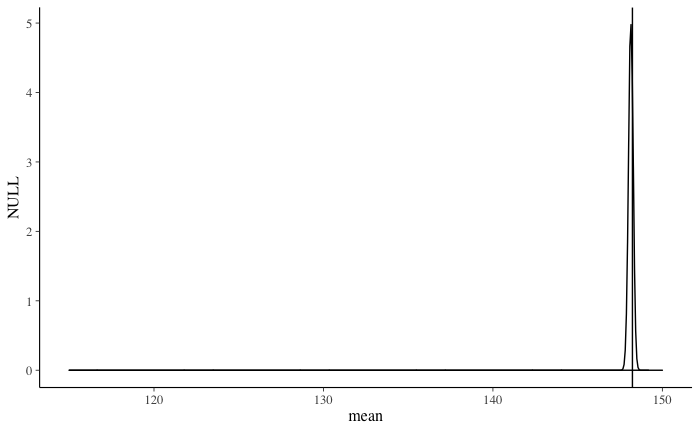

```r
ml.a.5.yhat_ppd <- (as.data.frame(ml.a.5.stanfit, pars = c("yhat_ppd")))
ppd.df <- data.frame(mean=apply(ml.a.5.yhat_ppd, 1, mean))
ppd.df$min <- apply(ml.a.5.yhat_ppd, 1, min)
ppd.df$max <- apply(ml.a.5.yhat_ppd, 1, max)
ppd.df$median <- apply(ml.a.5.yhat_ppd, 1, median)
ppd.df$range <- ppd.df$max - ppd.df$min
ppd.df.melt <- melt(ppd.df)
qplot(mean, geom="density", data=ppd.df)+
  geom_vline(xintercept=mean((shoes2$time_minutes)))+
  scale_x_continuous(limits = c(115, 150))
```

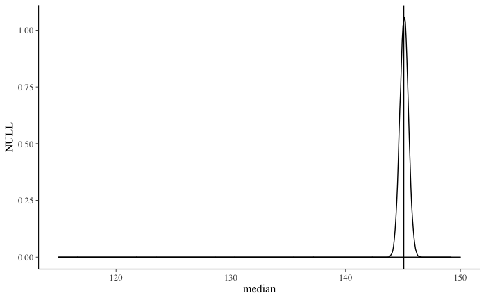

```r
qplot(median, geom="density", data=ppd.df)+
  geom_vline(xintercept=median((shoes2$time_minutes)))+
  scale_x_continuous(limits = c(115, 150))
```

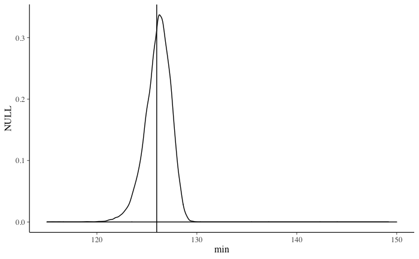

```r
qplot(min, geom="density", data=ppd.df)+
  geom_vline(xintercept=min((shoes2$time_minutes)))+
  scale_x_continuous(limits = c(115, 150))
```

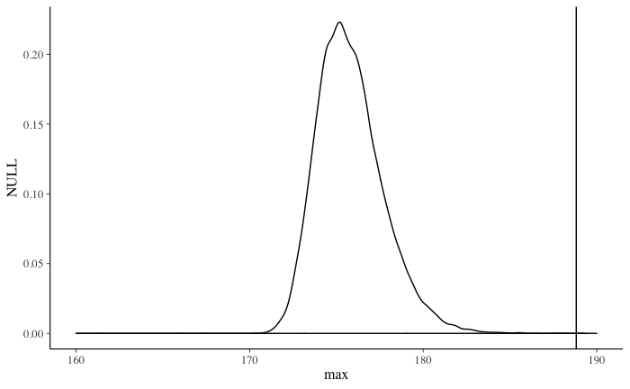

```r
qplot(max, geom="density", data=ppd.df)+
  geom_vline(xintercept=max((shoes2$time_minutes)))+
  scale_x_continuous(limits = c(160, 190))
```

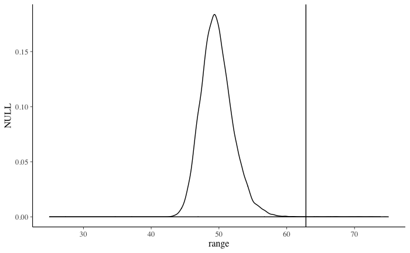

```r
qplot(range, geom="density", data=ppd.df)+
  geom_vline(xintercept=max((shoes2$time_minutes)) - min((shoes2$time_minutes)))+
  scale_x_continuous(limits = c(25, 75))
```

```r
#Calculate p-values
ml.a.5.ppd.pvals <- as.data.frame(
  c(
    mean(ppd.df$mean > mean(shoes2$time_minutes)),
    mean(ppd.df$median > median(shoes2$time_minutes)),
    mean(ppd.df$min > min(shoes2$time_minutes)),
    mean(ppd.df$max > max(shoes2$time_minutes)),
    mean(ppd.df$range > range(shoes2$time_minutes))
  )
)
ml.a.5.ppd.pvals <- t(ml.a.5.ppd.pvals)
colnames(ml.a.5.ppd.pvals) <- c("Mean", "Median", "Min", "Max", "Range")
rownames(ml.a.5.ppd.pvals) <- c("Bayesian p-value")
ml.a.5.ppd.pvals
```

```
                      Mean    Median     Min   Max        Range
Bayesian p-value 0.2443333 0.5397917 0.57375 5e-04 0.0001666667
```

MSE and MAD

```r
(ml.a.5.MAD.MSE.quant <- rbind(quantile(ml.a.5.MSE.ppd, probs = c(0.025, 0.975)), quantile(ml.a.5.MAD.ppd, probs = c(0.025, 0.975))))
```

```
          2.5%    97.5%
[1,] 18.352818 22.09617
[2,]  3.124232  3.46084
```

Table of quantiles for Vaporfly:gender

```r
c(median(ml.a.5.beta[,2]), median(ml.a.5.beta[,5]))
```

```
[1] -0.017091220  0.001486071
```

## Model 6 – Random age slope by marathon with heteroscedastic error variance with log(time) with student-t likelihood

Stan code

```r
ml.a.6.stancode <- "
data {
  int<lower=1> N;                               //Number of observations
  int<lower=1> P;                               //Number of predictors in X
  int<lower=1> M;                               //Number of marathons
  int<lower=1> Mp;                              //Number of marathon predictors
  int<lower=1> R;                               //Number of runners
  int<lower=1> VR;                              //Number of levels for vaporfly:runner
  int<lower=1> VM;                              //Number of levels for vaporfly:marathon
  int<lower=1, upper=M> marathon[N];            //Index of marathons
  int<lower=1, upper=R> runner[N];              //Index of runners
  int<lower=1, upper=VR> vaporfly_runner[N];    //Index of vaporfly:runner
  int<lower=1, upper=VM> vaporfly_marathon[N];  //Index of vaporfly:marathon
  matrix[N,P] X;                                //Fixed effects model matrix
  matrix[N,Mp] Z_m;                             //Marathon-level random effects model matrix
  vector[N] y;                                  //Response variable
}

transformed data {
  vector[N] logy;                               //Log-transformed response variable

  logy = log(y);
}

parameters {
  vector[P] beta;                               //Vector of fixed-effects coefficients
  real<lower=0> sigma_r;                        //Runner-level variance
  real<lower=0> sigma_vr;                       //Vaporfly:runner-level variance
  real<lower=0> sigma_vm;                       //Vaporfly:marathon-level variance
  vector<lower=0>[Mp] sigma_m;                  //Vector for marathon-level variances (intercept and slope for age)
  cholesky_factor_corr[Mp] L_m;                 //Cholesky decomposition of correlation matrix for marathon-level intercept and slope [2 x 2]
  real<lower=0> sigma_e[M];                     //Error variance -- separate for each marathon
  vector[R] r_raw;                              //Vector of unscaled runner-level random intercepts
  vector[VR] vr_raw;                            //Vector of unscaled vaporfly:runner-level random intercepts
  vector[VM] vm_raw;                            //Vector of unscaled vaporfly:marathon-level random intercepts
  vector[Mp] m_raw[M];                          //Array of vectors of unscaled marathon-level random intercepts and slopes
  real<lower=1> nu;                             //Degrees-of-freedom parameter for student-t likelihood
}

transformed parameters {
  vector[R] r;                                  //Vector of scaled runner-level random intercepts
  vector[VR] vr;                                //Vector of scaled vaporfly:runner-level random intercepts
  vector[VM] vm;                                //Vector of scaled vaporfly:marathon-level random intercepts
  vector[Mp] m[M];                              //Array of vectors of scaled marathon-level random intercepts and slopes

  {
    matrix[Mp, Mp] Sigma_m;                     //Marathon-level intercept and slope covariance matrix
    r = sigma_r * r_raw;                        //Create scaled runner-level random intercepts
    vr = sigma_vr * vr_raw;                     //Create scaled vaporfly:runner-level random intercepts
    vm = sigma_vm * vm_raw;                     //Create scaled vaporfly:marathon-level random intercepts

    Sigma_m = diag_pre_multiply(sigma_m, L_m);  //Create marathon=level intercept and slope covariance matrix using Cholesky decomposition
    for (a in 1:M) {
      m[a] = Sigma_m * m_raw[a];                //Create scaled marathon-level random intercepts and slopes
    }
  }
}

model {
  r_raw ~ std_normal();                         //Standard normal prior on unscaled runner-level random intercepts. Has effect of r ~ Normal(0, r_sigma).
  vr_raw ~ std_normal();                        //Standard normal prior on unscaled vaporfly:runner-level random intercepts. Has effect of vr ~ Normal(0, vr_sigma).
  vm_raw ~ std_normal();                        //Standard normal prior on unscaled vaporfly:marathon-level random intercepts. Has effect of vm ~ Normal(0, vm_sigma).
  for (b in 1:M) {
    to_vector(m_raw[b]) ~ std_normal();         //Independent standard normal priors on unscaled marathon-level random intercepts. Has effect of m ~ MultivariateNormal(c(0,0), Sigma_m).
    sigma_e[b] ~ cauchy(0,2);                   //Independent Cauchy priors on error variances for each marathon.
  }
  L_m ~ lkj_corr_cholesky(1);                   //LKJ prior on Cholesky correlation vector. With nu=1, imposes nearly uniform prior on correlation between intercept and slope.
  sigma_r ~ cauchy(0,2);                        //Cauchy prior on runner-level hypervariance parameter.
  for (c in 1:Mp) {
    sigma_m[c] ~ cauchy(0,2);                   //Independent Cauchy priors on marathon-level intercept and slope hypervariance parameters.
  }
  sigma_vr ~ cauchy(0,2);                       //Cauchy prior on vaporfly:runner-level hypervariance parameter.
  sigma_vm ~ cauchy(0,2);                       //Cauchy prior on vaporfly:marathon-level hypervariance parameter.

  //Likelihood                                  //Normal likelihood function with mixed effects linear predictor and homoscedastic error variance assumption.
  for (i in 1:N) {
     logy[i] ~ student_t(nu, X[i,]*beta + Z_m[i,]*m[marathon[i]] + r[runner[i]] + vr[vaporfly_runner[i]] + vm[vaporfly_marathon[i]], sigma_e[marathon[i]]);
  }
}

generated quantities {
  vector[N] residuals;                          //Vector for residuals
  vector[N] yhat;                               //Vector for estimated linear predictor
  vector[N] yhat_ppd;                           //Vector for posterior predictive distribution
  vector[N] log_lik;                            //Vector for log-likelihood values for WAIC calculation

  for (j in 1:N) {
    //Samples for the linear predictor yhat
    yhat[j] = exp(X[j,]*beta + Z_m[j,]*m[marathon[j]] + r[runner[j]] + vr[vaporfly_runner[j]] + vm[vaporfly_marathon[j]]);
    //Samples for the posterior predictive distribution, which includes error uncertainty
    yhat_ppd[j] = student_t_rng(nu, exp(X[j,]*beta + Z_m[j,]*m[marathon[j]] + r[runner[j]] + vr[vaporfly_runner[j]] + vm[vaporfly_marathon[j]]), sigma_e[marathon[j]]);
    //Samples of log-likelihood for WAIC calculation
    log_lik[j] = student_t_lpdf(logy[j] | nu, (X[j,]*beta + Z_m[j,]*m[marathon[j]] + r[runner[j]] + vr[vaporfly_runner[j]] + vm[vaporfly_marathon[j]]), sigma_e[marathon[j]]);
  }

  residuals = y - yhat;                         //Define residuals as y - hat

}

"
```

Define the data for stan

```r
ml.a.6.X <- model.matrix(~ vaporfly*gender + gender*age, data=shoes2)
ml.a.6.Z_m <- model.matrix(~ 1 + age, data=shoes2)
ml.a.6.standata <- list(
  N = nrow(ml.a.6.X),
  P = ncol(ml.a.6.X),
  Mp = ncol(ml.a.6.Z_m),
  M = length(unique(as.integer(factor(shoes2$marathon)))),
  R = length(unique(as.integer(factor(shoes2$match_name)))),
  VM = length(unique(as.integer(factor(shoes2$vaporfly_marathon)))),
  VR = length(unique(as.integer(factor(shoes2$vaporfly_runner)))),
  marathon = as.integer(factor(shoes2$marathon)),
  runner = as.integer(factor(shoes2$match_name)),
  vaporfly_marathon = as.integer(factor(shoes2$vaporfly_marathon)),
  vaporfly_runner = as.integer(factor(shoes2$vaporfly_runner)),
  X = ml.a.6.X,
  Z_m = ml.a.6.Z_m,
  y = shoes2$time_minutes
)
```

Set initial values

```r
Mp = ncol(ml.a.6.Z_m)
M = length(unique(as.integer(factor(shoes2$marathon))))
R = length(unique(as.integer(factor(shoes2$match_name))))
VM = length(unique(as.integer(factor(shoes2$vaporfly_marathon))))
VR = length(unique(as.integer(factor(shoes2$vaporfly_runner))))
marathon = as.integer(factor(shoes2$marathon))
runner = as.integer(factor(shoes2$match_name))
vaporfly_marathon = as.integer(factor(shoes2$vaporfly_marathon))
vaporfly_runner = as.integer(factor(shoes2$vaporfly_runner))

initf2 <- function(chain_id = 1) {
  # cat("chain_id =", chain_id, "\n")
  list(beta = array(rnorm(ncol(ml.a.6.X), sd=0.1), dim = c(ncol(ml.a.6.X))),
       sigma_r = 1,
       sigma_vr = 1,
       sigma_vm = 1,
       sigma_m = array(rlnorm(Mp, sdlog = 0.1), dim = Mp),
       sigma_e = array(rlnorm(M, sdlog = 0.1), dim=M),
       r_raw = array(rnorm(R, sd=0.1), dim=R),
       vr_raw = array(rnorm(VR, sd=0.1), dim=VR),
       vm_raw = array(rnorm(VM, sd=0.1), dim=VM),
       m_raw = array(rnorm(M*2, sd=0.1), dim = c(M,2)),
       nu = 1.1
       )
}

# generate a list of lists to specify initial values
n_chains <- 4
init_ll <- lapply(1:n_chains, function(id) initf2(chain_id = id))
```

Run the model

```r
ml.a.6.stanfit <- stan(
  model_code = ml.a.6.stancode,
  data=ml.a.6.standata,
  control = list(max_treedepth = 15, adapt_delta=0.9),
  init = init_ll,
  chains=3,
  warmup=2000,
  iter=18000,
  cores=3
)
```

WAIC

```r
ml.a.6.stanfit.loglik <- extract_log_lik(ml.a.6.stanfit)
fbar <- colMeans(exp(ml.a.6.stanfit.loglik))
Pw <- sum(apply(ml.a.6.stanfit.loglik, 2, var))
WAIC <- -2*sum(log(fbar)) + 2*Pw
WAIC #-4517, -4518.375, -4524.9, -4527.1, -4525.9
```

This is the best-fitting model yet, so let’s go with this one.

Look at MCMC chain convergence

```r
#Look at traceplots
plot(ml.a.6.stanfit, plotfun = "trace", pars = c("beta"))
plot(ml.a.6.stanfit, plotfun = "trace", pars = c("m"))
plot(ml.a.6.stanfit, plotfun = "trace", pars = c("sigma_e"))
#Looks like the chains mixed well

#Look at Gelman-Rubin statistic -- exclude NAs because the Cholesky factorization of the correlation matrix has 1 and 0 by definition, so their GR statistics are N/A
c(min(na.exclude(summary(ml.a.6.stanfit)$summary[,10])), max(na.exclude(summary(ml.a.6.stanfit)$summary[,10])))
#Look at the min ESS
summary(na.exclude(summary(ml.a.6.stanfit, pars = c("beta","r","m","vr","vm","sigma_r","sigma_vr","sigma_vm","sigma_m","sigma_e","nu"))$summary[,9]))
```

Residuals

```r
#Extract summary of draws of the residuals
ml.a.6.resids <- summary(ml.a.6.stanfit, pars = c("residuals"), probs=0.5)$summary
#Take the mean of the draws for each residual and studentize them
ml.a.6.student.resids <- ml.a.6.resids[,1]/sd(ml.a.6.resids[,1])
#Extract degrees-of-freedom draws
ml.a.6.nu <- summary(ml.a.6.stanfit, pars = c("nu"), probs=0.5)$summary
#Make a density plot of the studentized residuals and random t-distribution variates
student.resid <- data.frame(student=rt(n=length(ml.a.6.student.resids), df=ml.a.6.nu[,1]), ml.a.6.student.resids = ml.a.6.student.resids)
student.resid.melt <- melt(student.resid)
ggplot(student.resid.melt, aes(x=value, alpha=0.3, fill=variable))+
  geom_density()+
  scale_fill_discrete(name="Data", labels = c("Student-t variates", "Studentized model residuals"))+
  scale_alpha_continuous(guide = F)
#Make a qqplot comparing the residuals to draws from a student-t distribution with the same degrees of freedom as our estimate
qqplot(qt(ppoints(nrow(shoes2)), df = ml.a.6.nu[,1]), ml.a.6.student.resids, xlab="Theoretical Quantiles", ylab="Sample Quantiles", main="Student-t Q-Q Plot"); qqline(ml.a.6.student.resids, distribution=function(p) qt(p, df=ml.a.6.nu[,1]), probs=c(0.025, 0.975), col=1)
```

Posterior predictive checks

MSE and MAD

```r
ml.a.6.MSE.ppd <- apply(apply(ml.a.6.yhat_ppd, 1, FUN = function(x) (x-shoes2$time_minutes)^2), 2, mean)
ml.a.6.MAD.ppd <- apply(apply(ml.a.6.yhat_ppd, 1, FUN = function(x) abs(x-shoes2$time_minutes)), 2, mean)
(ml.a.6.MAD.MSE.quant <- rbind(quantile(ml.a.6.MSE.ppd, probs = c(0.025, 0.975)), quantile(ml.a.6.MAD.ppd, probs = c(0.025, 0.975))))
```

```
          2.5%     97.5%
[1,] 18.786279 22.485259
[2,]  2.872598  3.183349
```

```r
write.csv(ml.a.6.MAD.MSE.quant, file="/Users/tschappe/Documents/NC\ State\ Classes/ST540/Take\ Home\ Exam/ml.a.6.MAD.MSE.quant.csv")
```

Look at results

```r
print(ml.a.6.stanfit, pars = c("beta"))
print(ml.a.6.stanfit, pars = c("r"))
print(ml.a.6.stanfit, pars = c("m"))
print(ml.a.6.stanfit, pars = c("vr"))
print(ml.a.6.stanfit, pars = c("vm"))
print(ml.a.6.stanfit, pars = c("L_m"))
print(ml.a.6.stanfit, pars = c("sigma_m"))
print(ml.a.6.stanfit, pars = c("sigma_r"))
print(ml.a.6.stanfit, pars = c("sigma_vr"))
print(ml.a.6.stanfit, pars = c("sigma_vm"))
print(ml.a.6.stanfit, pars = c("sigma_e"))
print(ml.a.6.stanfit, pars = c("yhat"))
print(ml.a.6.stanfit, pars = c("residuals"))
```

```r
L = as.matrix(rbind(c(1,0), c(0.2, sqrt(1-0.2^2))))
tau = as.matrix(rbind(c(1.2,0), c(0, 1.8)))
corr.mat <- tau %*% L
cov.mat <- corr.mat %*% t(corr.mat)
corr.mat
cov.mat
```

## Model 5 Vapor:Runner reduced

Stan code

```r
ml.a.5.vr.red.stancode <- '
data {
  int<lower=1> N;                               //Number of observations
  int<lower=1> P;                               //Number of predictors in X
  int<lower=1> M;                               //Number of marathons
  int<lower=1> Mp;                              //Number of marathon predictors
  int<lower=1> R;                               //Number of runners
  //int<lower=1> VR;                              //Number of levels for vaporfly:runner
  int<lower=1> VM;                              //Number of levels for vaporfly:marathon
  int<lower=1, upper=M> marathon[N];            //Index of marathons
  int<lower=1, upper=R> runner[N];              //Index of runners
  //int<lower=1, upper=VR> vaporfly_runner[N];    //Index of vaporfly:runner
  int<lower=1, upper=VM> vaporfly_marathon[N];  //Index of vaporfly:marathon
  matrix[N,P] X;                                //Fixed effects model matrix
  matrix[N,Mp] Z_m;                             //Marathon-level random effects model matrix
  vector[N] y;                                  //Response variable
}

transformed data {
  vector[N] logy;                               //Log-transformed response variable

  logy = log(y);
}

parameters {
  vector[P] beta;                               //Vector of fixed-effects coefficients
  real<lower=0> sigma_r;                        //Runner-level variance
  //real<lower=0> sigma_vr;                       //Vaporfly:runner-level variance
  real<lower=0> sigma_vm;                       //Vaporfly:marathon-level variance
  vector<lower=0>[Mp] sigma_m;                  //Vector for marathon-level variances (intercept and slope for age)
  cholesky_factor_corr[Mp] L_m;                 //Correlation vector (Cholesky decomposition) of marathon-level intercept and slope
  real<lower=0> sigma_e[M];                     //Error variance -- separate for each marathon
  vector[R] r_raw;                              //Vector of unscaled runner-level random intercepts
  //vector[VR] vr_raw;                            //Vector of unscaled vaporfly:runner-level random intercepts
  vector[VM] vm_raw;                            //Vector of unscaled vaporfly:marathon-level random intercepts
  vector[Mp] m_raw[M];                          //Array of vectors of unscaled marathon-level random intercepts and slopes
}

transformed parameters {
  vector[R] r;                                  //Vector of scaled runner-level random intercepts
  //vector[VR] vr;                                //Vector of scaled vaporfly:runner-level random intercepts
  vector[VM] vm;                                //Vector of scaled vaporfly:marathon-level random intercepts
  vector[Mp] m[M];                              //Array of vectors of scaled marathon-level random intercepts and slopes

  {
    matrix[Mp, Mp] Sigma_m;                     //Marathon-level intercept and slope covariance matrix
    r = sigma_r * r_raw;                        //Create scaled runner-level random intercepts
    //vr = sigma_vr * vr_raw;                     //Create scaled vaporfly:runner-level random intercepts
    vm = sigma_vm * vm_raw;                     //Create scaled vaporfly:marathon-level random intercepts

    Sigma_m = diag_pre_multiply(sigma_m, L_m);  //Create marathon=level intercept and slope covariance matrix using Cholesky decomposition
    for (a in 1:M) {
      m[a] = Sigma_m * m_raw[a];                //Create scaled marathon-level random intercepts and slopes
    }
  }
}

model {
  r_raw ~ std_normal();                         //Standard normal prior on unscaled runner-level random intercepts. Has effect of r ~ Normal(0, r_sigma).
  //vr_raw ~ std_normal();                        //Standard normal prior on unscaled vaporfly:runner-level random intercepts. Has effect of vr ~ Normal(0, vr_sigma).
  vm_raw ~ std_normal();                        //Standard normal prior on unscaled vaporfly:marathon-level random intercepts. Has effect of vm ~ Normal(0, vm_sigma).
  for (b in 1:M) {
    to_vector(m_raw[b]) ~ std_normal();         //Standard normal prior on unscaled marathon-level random intercepts. Has effect of m ~ MultivariateNormal(c(0,0), Sigma_m).
    sigma_e[b] ~ cauchy(0,2);                   //Independent Cauchy priors on error variances for each marathon.
  }
  L_m ~ lkj_corr_cholesky(1);                   //LKJ prior on Cholesky correlation vector. Imposes uniform prior on correlation between intercept and slope.
  sigma_r ~ cauchy(0,2);                        //Cauchy prior on runner-level hypervariance parameter.
  for (c in 1:Mp) {
    sigma_m[c] ~ cauchy(0,2);                   //Independent Cauchy priors on marathon-level intercept and slope hypervariance parameters.
  }
  //sigma_vr ~ cauchy(0,2);                       //Cauchy prior on vaporfly:runner-level hypervariance parameter.
  sigma_vm ~ cauchy(0,2);                       //Cauchy prior on vaporfly:marathon-level hypervariance parameter.

  //Likelihood                                  //Normal likelihood function with mixed effects linear predictor and homoscedastic error variance assumption.
  for (i in 1:N) {
     logy[i] ~ normal(X[i,]*beta + Z_m[i,]*m[marathon[i]] + r[runner[i]] + vm[vaporfly_marathon[i]], sigma_e[marathon[i]]);
  }
}

generated quantities {
  vector[N] residuals;                          //Vector for residuals
  vector[N] yhat;                               //Vector for estimated linear predictor
  vector[N] yhat_ppd;                           //Vector for posterior predictive distribution
  vector[N] log_lik;                            //Vector for log-likelihood values for WAIC calculation

  for (j in 1:N) {
    //Samples for the linear predictor yhat
    yhat[j] = exp(X[j,]*beta + Z_m[j,]*m[marathon[j]] + r[runner[j]] + vm[vaporfly_marathon[j]]);
    //Samples for the posterior predictive distribution, which includes error uncertainty
    yhat_ppd[j] = normal_rng(exp(X[j,]*beta + Z_m[j,]*m[marathon[j]] + r[runner[j]] + vm[vaporfly_marathon[j]]), sigma_e[marathon[j]]);
    //Samples of log-likelihood for WAIC calculation
    log_lik[j] = normal_lpdf(logy[j] | (X[j,]*beta + Z_m[j,]*m[marathon[j]] + r[runner[j]] + vm[vaporfly_marathon[j]]), sigma_e[marathon[j]]);
  }

  residuals = y - yhat;                         //Define residuals as y - hat

}

'
```

Define the data for stan

```r
ml.a.5.vr.red.X <- model.matrix(~ vaporfly*gender + gender*age, data=shoes2)
ml.a.5.vr.red.Z_m <- model.matrix(~ 1 + age, data=shoes2)
ml.a.5.vr.red.standata <- list(
  N = nrow(ml.a.5.vr.red.X),
  P = ncol(ml.a.5.vr.red.X),
  Mp = ncol(ml.a.5.vr.red.Z_m),
  M = length(unique(as.integer(factor(shoes2$marathon)))),
  R = length(unique(as.integer(factor(shoes2$match_name)))),
  VM = length(unique(as.integer(factor(shoes2$vaporfly_marathon)))),
  #VR = length(unique(as.integer(factor(shoes2$vaporfly_runner)))),
  marathon = as.integer(factor(shoes2$marathon)),
  runner = as.integer(factor(shoes2$match_name)),
  vaporfly_marathon = as.integer(factor(shoes2$vaporfly_marathon)),
  #vaporfly_runner = as.integer(factor(shoes2$vaporfly_runner)),
  X = ml.a.5.vr.red.X,
  Z_m = ml.a.5.vr.red.Z_m,
  y = shoes2$time_minutes
)
```

Set initial values

```r
Mp = ncol(ml.a.5.vr.red.Z_m)
M = length(unique(as.integer(factor(shoes2$marathon))))
R = length(unique(as.integer(factor(shoes2$match_name))))
VM = length(unique(as.integer(factor(shoes2$vaporfly_marathon))))
VR = length(unique(as.integer(factor(shoes2$vaporfly_runner))))
marathon = as.integer(factor(shoes2$marathon))
runner = as.integer(factor(shoes2$match_name))
vaporfly_marathon = as.integer(factor(shoes2$vaporfly_marathon))
vaporfly_runner = as.integer(factor(shoes2$vaporfly_runner))

initf2.norm <- function(chain_id = 1) {
  # cat("chain_id =", chain_id, "\n")
  list(beta = array(rnorm(ncol(ml.a.6.X), sd=0.1), dim = c(ncol(ml.a.6.X))),
       sigma_r = 1,
       #sigma_vr = 1,
       sigma_vm = 1,
       sigma_m = array(rlnorm(Mp, sdlog = 0.1), dim = Mp),
       sigma_e = array(rlnorm(M, sdlog = 0.1), dim=M),
       r_raw = array(rnorm(R, sd=0.1), dim=R),
       #vr_raw = array(rnorm(VR, sd=0.1), dim=VR),
       vm_raw = array(rnorm(VM, sd=0.1), dim=VM),
       m_raw = array(rnorm(M*2, sd=0.1), dim = c(M,2))
       )
}

# generate a list of lists to specify initial values
n_chains <- 3
init_ll.norm <- lapply(1:n_chains, function(id) initf2.norm(chain_id = id))
```

Run the model

```r
ml.a.5.vr.red.stanfit <- stan(
  model_code = ml.a.5.vr.red.stancode,
  data=ml.a.5.vr.red.standata,
  control = list(max_treedepth = 15, adapt_delta=0.9),
  init = init_ll.norm,
  chains=3,
  warmup=3000,
  iter=11000,
  cores=3
)
```

Run a loop of the model and calculate WAIC for each one

```r
B <- 5
ml.a.5.vr.red.stanfit.list <- list(NULL)
for (i in 1:B) {
  ml.a.5.vr.red.stanfit.list[[i]] <- stan(
  model_code = ml.a.5.vr.red.stancode,
  data=ml.a.5.vr.red.standata,
  control = list(max_treedepth = 15, adapt_delta=0.9),
  init = init_ll.norm,
  chains=3,
  warmup=1000,
  iter=4000,
  cores=3
)
}

ml.a.5.vr.red.log.lik.list <- lapply(ml.a.5.vr.red.stanfit.list, FUN = extract_log_lik)
ml.a.5.vr.red.fbar.list <- lapply(ml.a.5.vr.red.log.lik.list, FUN = function(x) colMeans(exp(x)))
ml.a.5.vr.red.Pw.list <- lapply(ml.a.5.vr.red.log.lik.list, FUN = function(x) sum(apply(x, 2, var)))
ml.a.5.vr.red.WAIC.1.list <- lapply(ml.a.5.vr.red.fbar.list, FUN = function(x) -2*sum(log(x)))
ml.a.5.vr.red.WAIC.2.list <- lapply(ml.a.5.vr.red.Pw.list, FUN = function(x) 2*x)
ml.a.5.vr.red.WAIC <- 1:B
for (i in 1:B) {
  ml.a.5.vr.red.WAIC[i] <- ml.a.5.vr.red.WAIC.1.list[[i]] + ml.a.5.vr.red.WAIC.2.list[[i]]
}
(ml.a.5.vr.red.WAIC.quant <- quantile(probs = c(0.025, 0.975), ml.a.5.vr.red.WAIC))
write.csv(ml.a.5.vr.red.WAIC.quant, file="/Users/tschappe/Documents/NC\ State\ Classes/ST540/Take\ Home\ Exam/ml.a.5.vr.red.WAIC.quant.csv")
```

WAIC

```r
ml.a.5.vr.red.loglik <- extract_log_lik(ml.a.5.vr.red.stanfit)
fbar <- colMeans(exp(ml.a.5.vr.red.loglik))
Pw <- sum(apply(ml.a.5.vr.red.loglik, 2, var))
WAIC <- -2*sum(log(fbar)) + 2*Pw
WAIC #-4461
```

## Model 5 Vapor:Marathon reduced

Stan code

```r
ml.a.5.vm.red.stancode <- '
data {
  int<lower=1> N;                               //Number of observations
  int<lower=1> P;                               //Number of predictors in X
  int<lower=1> M;                               //Number of marathons
  int<lower=1> Mp;                              //Number of marathon predictors
  int<lower=1> R;                               //Number of runners
  int<lower=1> VR;                              //Number of levels for vaporfly:runner
  //int<lower=1> VM;                              //Number of levels for vaporfly:marathon
  int<lower=1, upper=M> marathon[N];            //Index of marathons
  int<lower=1, upper=R> runner[N];              //Index of runners
  int<lower=1, upper=VR> vaporfly_runner[N];    //Index of vaporfly:runner
  //int<lower=1, upper=VM> vaporfly_marathon[N];  //Index of vaporfly:marathon
  matrix[N,P] X;                                //Fixed effects model matrix
  matrix[N,Mp] Z_m;                             //Marathon-level random effects model matrix
  vector[N] y;                                  //Response variable
}

transformed data {
  vector[N] logy;                               //Log-transformed response variable

  logy = log(y);
}

parameters {
  vector[P] beta;                               //Vector of fixed-effects coefficients
  real<lower=0> sigma_r;                        //Runner-level variance
  real<lower=0> sigma_vr;                       //Vaporfly:runner-level variance
  //real<lower=0> sigma_vm;                       //Vaporfly:marathon-level variance
  vector<lower=0>[Mp] sigma_m;                  //Vector for marathon-level variances (intercept and slope for age)
  cholesky_factor_corr[Mp] L_m;                 //Correlation vector (Cholesky decomposition) of marathon-level intercept and slope
  real<lower=0> sigma_e[M];                     //Error variance -- separate for each marathon
  vector[R] r_raw;                              //Vector of unscaled runner-level random intercepts
  vector[VR] vr_raw;                            //Vector of unscaled vaporfly:runner-level random intercepts
  //vector[VM] vm_raw;                            //Vector of unscaled vaporfly:marathon-level random intercepts
  vector[Mp] m_raw[M];                          //Array of vectors of unscaled marathon-level random intercepts and slopes
}

transformed parameters {
  vector[R] r;                                  //Vector of scaled runner-level random intercepts
  vector[VR] vr;                                //Vector of scaled vaporfly:runner-level random intercepts
  //vector[VM] vm;                                //Vector of scaled vaporfly:marathon-level random intercepts
  vector[Mp] m[M];                              //Array of vectors of scaled marathon-level random intercepts and slopes

  {
    matrix[Mp, Mp] Sigma_m;                     //Marathon-level intercept and slope covariance matrix
    r = sigma_r * r_raw;                        //Create scaled runner-level random intercepts
    vr = sigma_vr * vr_raw;                     //Create scaled vaporfly:runner-level random intercepts
    //vm = sigma_vm * vm_raw;                     //Create scaled vaporfly:marathon-level random intercepts

    Sigma_m = diag_pre_multiply(sigma_m, L_m);  //Create marathon=level intercept and slope covariance matrix using Cholesky decomposition
    for (a in 1:M) {
      m[a] = Sigma_m * m_raw[a];                //Create scaled marathon-level random intercepts and slopes
    }
  }
}

model {
  r_raw ~ std_normal();                         //Standard normal prior on unscaled runner-level random intercepts. Has effect of r ~ Normal(0, r_sigma).
  vr_raw ~ std_normal();                        //Standard normal prior on unscaled vaporfly:runner-level random intercepts. Has effect of vr ~ Normal(0, vr_sigma).
  //vm_raw ~ std_normal();                        //Standard normal prior on unscaled vaporfly:marathon-level random intercepts. Has effect of vm ~ Normal(0, vm_sigma).
  for (b in 1:M) {
    to_vector(m_raw[b]) ~ std_normal();         //Standard normal prior on unscaled marathon-level random intercepts. Has effect of m ~ MultivariateNormal(c(0,0), Sigma_m).
    sigma_e[b] ~ cauchy(0,2);                   //Independent Cauchy priors on error variances for each marathon.
  }
  L_m ~ lkj_corr_cholesky(1);                   //LKJ prior on Cholesky correlation vector. Imposes uniform prior on correlation between intercept and slope.
  sigma_r ~ cauchy(0,2);                        //Cauchy prior on runner-level hypervariance parameter.
  for (c in 1:Mp) {
    sigma_m[c] ~ cauchy(0,2);                   //Independent Cauchy priors on marathon-level intercept and slope hypervariance parameters.
  }
  sigma_vr ~ cauchy(0,2);                       //Cauchy prior on vaporfly:runner-level hypervariance parameter.
  //sigma_vm ~ cauchy(0,2);                       //Cauchy prior on vaporfly:marathon-level hypervariance parameter.

  //Likelihood                                  //Normal likelihood function with mixed effects linear predictor and homoscedastic error variance assumption.
  for (i in 1:N) {
     logy[i] ~ normal(X[i,]*beta + Z_m[i,]*m[marathon[i]] + r[runner[i]] + vr[vaporfly_runner[i]], sigma_e[marathon[i]]);
  }
}

generated quantities {
  vector[N] residuals;                          //Vector for residuals
  vector[N] yhat;                               //Vector for estimated linear predictor
  vector[N] yhat_ppd;                           //Vector for posterior predictive distribution
  vector[N] log_lik;                            //Vector for log-likelihood values for WAIC calculation

  for (j in 1:N) {
    //Samples for the linear predictor yhat
    yhat[j] = exp(X[j,]*beta + Z_m[j,]*m[marathon[j]] + r[runner[j]] + vr[vaporfly_runner[j]]);
    //Samples for the posterior predictive distribution, which includes error uncertainty
    yhat_ppd[j] = normal_rng(exp(X[j,]*beta + Z_m[j,]*m[marathon[j]] + r[runner[j]] + vr[vaporfly_runner[j]]), sigma_e[marathon[j]]);
    //Samples of log-likelihood for WAIC calculation
    log_lik[j] = normal_lpdf(logy[j] | (X[j,]*beta + Z_m[j,]*m[marathon[j]] + r[runner[j]] + vr[vaporfly_runner[j]]), sigma_e[marathon[j]]);
  }

  residuals = y - yhat;                         //Define residuals as y - hat

}

'
```

Define the data for stan

```r
ml.a.5.vm.red.X <- model.matrix(~ vaporfly*gender + gender*age, data=shoes2)
ml.a.5.vm.red.Z_m <- model.matrix(~ 1 + age, data=shoes2)
ml.a.5.vm.red.standata <- list(
  N = nrow(ml.a.5.vm.red.X),
  P = ncol(ml.a.5.vm.red.X),
  Mp = ncol(ml.a.5.vm.red.Z_m),
  M = length(unique(as.integer(factor(shoes2$marathon)))),
  R = length(unique(as.integer(factor(shoes2$match_name)))),
  VM = length(unique(as.integer(factor(shoes2$vaporfly_marathon)))),
  VR = length(unique(as.integer(factor(shoes2$vaporfly_runner)))),
  marathon = as.integer(factor(shoes2$marathon)),
  runner = as.integer(factor(shoes2$match_name)),
  vaporfly_marathon = as.integer(factor(shoes2$vaporfly_marathon)),
  vaporfly_runner = as.integer(factor(shoes2$vaporfly_runner)),
  X = ml.a.5.vm.red.X,
  Z_m = ml.a.5.vm.red.Z_m,
  y = shoes2$time_minutes
)
```

Set initial values

```r
Mp = ncol(ml.a.5.vm.red.Z_m)
M = length(unique(as.integer(factor(shoes2$marathon))))
R = length(unique(as.integer(factor(shoes2$match_name))))
VM = length(unique(as.integer(factor(shoes2$vaporfly_marathon))))
VR = length(unique(as.integer(factor(shoes2$vaporfly_runner))))
marathon = as.integer(factor(shoes2$marathon))
runner = as.integer(factor(shoes2$match_name))
vaporfly_marathon = as.integer(factor(shoes2$vaporfly_marathon))
vaporfly_runner = as.integer(factor(shoes2$vaporfly_runner))

initf2.norm <- function(chain_id = 1) {
  # cat("chain_id =", chain_id, "\n")
  list(beta = array(rnorm(ncol(ml.a.5.vm.red.X), sd=0.1), dim = c(ncol(ml.a.5.vm.red.X))),
       sigma_r = 1,
       sigma_vr = 1,
       sigma_vm = 1,
       sigma_m = array(rlnorm(Mp, sdlog = 0.1), dim = Mp),
       sigma_e = array(rlnorm(M, sdlog = 0.1), dim=M),
       r_raw = array(rnorm(R, sd=0.1), dim=R),
       vr_raw = array(rnorm(VR, sd=0.1), dim=VR),
       vm_raw = array(rnorm(VM, sd=0.1), dim=VM),
       m_raw = array(rnorm(M*2, sd=0.1), dim = c(M,2))
       )
}

# generate a list of lists to specify initial values
n_chains <- 3
init_ll.norm <- lapply(1:n_chains, function(id) initf2.norm(chain_id = id))
```

Run the model

```r
ml.a.5.vm.red.stanfit <- stan(
  model_code = ml.a.5.vm.red.stancode,
  data=ml.a.5.vm.red.standata,
  control = list(max_treedepth = 15, adapt_delta=0.9),
  init = init_ll.norm,
  chains=3,
  warmup=3000,
  iter=11000,
  cores=3
)
```

Run a loop of the model

```r
(ml.a.5.vm.red.WAIC.quant <- quantile(probs = c(0.025, 0.975), c(ml.a.5.vm.red.WAIC, -4477)))
```

```
     2.5%     97.5%
-4480.428 -4477.162
```

WAIC

```r
ml.a.5.vm.red.stanfit.loglik <- extract_log_lik(ml.a.5.vm.red.stanfit)
fbar <- colMeans(exp(ml.a.5.vm.red.stanfit.loglik))
Pw <- sum(apply(ml.a.5.vm.red.stanfit.loglik, 2, var))
WAIC <- -2*sum(log(fbar)) + 2*Pw
WAIC #-4476.9
```